# MapDocument

Anna Cook

11/9/2020

# Introduction

The purpose of this assignment was to create maps showing the track and total rainfall for two different hurricanes: Hurricane Floyd, which occurred in 1999, and Hurricane Allison, which occurred in 2001. The data was collected from a github repository from the user [Geanders](https://github.com/geanders/hurricaneexposure) and the [FEMA website](https://www.fema.gov/disasters/disaster-declarations).

In order to map these hurricanes, the data first had to be cleaned, and several datasets had to be merged together. The process is described briefly below.

# Data Description

The data was first read into R from the github repository and the FEMA website. The rainfall data and hurricane tracking data were in two separate datasets. These were filtered down to include only the hurricanes of interest. Then these datasets had to be merged with state and county mapping data from the “maps” R package. The state and county data was filtered to include only the states of interest. The final datasets can be previewed below.

#### Tidy Dataset for Hurricane Floyd

```
##         long      lat group order  region subregion fips   rain
## 1  -86.50517 32.34920     1     1 alabama   autauga 1001 [0,25]
## 2  -86.53382 32.35493     1     2 alabama   autauga 1001 [0,25]
## 3  -86.54527 32.36639     1     3 alabama   autauga 1001 [0,25]
## 4  -86.55673 32.37785     1     4 alabama   autauga 1001 [0,25]
## 5  -86.57966 32.38357     1     5 alabama   autauga 1001 [0,25]
## 6  -86.59111 32.37785     1     6 alabama   autauga 1001 [0,25]
## 7  -86.61403 32.38931     1     7 alabama   autauga 1001 [0,25]
## 8  -86.61976 32.40649     1     8 alabama   autauga 1001 [0,25]
## 9  -86.62549 32.41795     1     9 alabama   autauga 1001 [0,25]
## 10 -86.63695 32.41795     1    10 alabama   autauga 1001 [0,25]
```

#### Tidy Dataset for Hurricane Allison

```
##         long      lat group order  region subregion fips      rain
## 1  -86.50517 32.34920     1     1 alabama   autauga 1001 Unexposed
## 2  -86.53382 32.35493     1     2 alabama   autauga 1001 Unexposed
## 3  -86.54527 32.36639     1     3 alabama   autauga 1001 Unexposed
## 4  -86.55673 32.37785     1     4 alabama   autauga 1001 Unexposed
## 5  -86.57966 32.38357     1     5 alabama   autauga 1001 Unexposed
## 6  -86.59111 32.37785     1     6 alabama   autauga 1001 Unexposed
## 7  -86.61403 32.38931     1     7 alabama   autauga 1001 Unexposed
## 8  -86.61976 32.40649     1     8 alabama   autauga 1001 Unexposed
## 9  -86.62549 32.41795     1     9 alabama   autauga 1001 Unexposed
## 10 -86.63695 32.41795     1    10 alabama   autauga 1001 Unexposed
```

# Maps

Once the data was cleaned, the next step was to map the data for each hurricane on two separate maps using the ggplot2 R package. For the Hurricane Floyd map, the rainfall data was displayed using intervals of 25 mm. For the Hurricane Allison map, the rainfall data was displayed using a binary variable corresponding to “exposed” if the county got hit with at least 175 mm of rain, and “unexposed” otherwise. These maps are shown below.

### Floyd-1999 Map

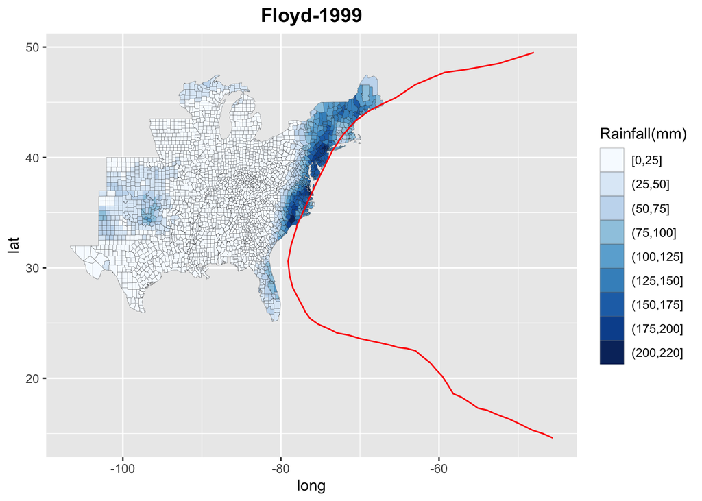

### Allison-2001 Map

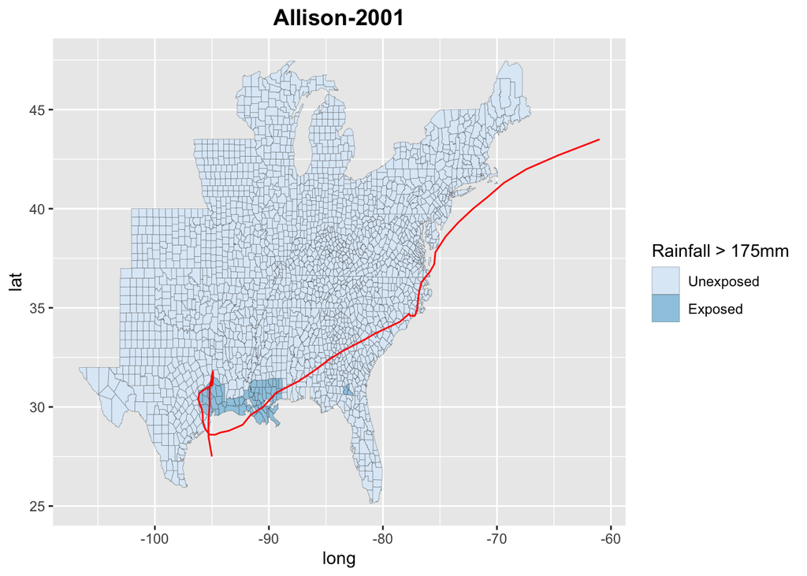

# Discussion

These maps were produced using ggplot2, but similar maps can be created using the “usmaps,” “tmap,” or “leaflet” R packages. For the sake of simplicity, maps using these other packages were excluded from this presentation. Additionally, future work may aim to add more features to the plots, such as wind speeds or property damage.

# Resources

### R Packages

- maps
- hurricaneexposuredata
- tidyverse
- drat
- magrittr
- readr
- ggplot2

### Data Collected from

- https://github.com/geanders/hurricaneexposure
- https://www.fema.gov/disasters/disaster-declarations